# Bingyu

Bingyu Sun

12/10/2018

## Data Import

```r
cancer_raw =
  read_csv("./data/Cancer_Registry.csv") %>%
  janitor::clean_names() %>%
  select(target_death_rate, geography, everything()) %>%
  separate(geography, into = c("county", "state"), sep = ",")
```

**Variables**

- **target_death_rate:** mean per capita (100,000) cancer mortalities (a)
- **avg_ann_count:** mean number of reported cases of cancer diagnosed annually (a)
- **avg_deaths_per_year:** mean number of reported mortalities due to cancer (a)
- **incidence_rate:** mean per capita (100,000) cancer diagnoses (a)
- **med_income:** median income per county (b)
- **pop_est2015:** population of county (b)
- **poverty_percent:** percent of population in poverty (b)
- **study_per_cap** per capita number of cancer-related clinical trials per county (a)
- **binned_inc:** median income per capita binned by decile (b)
- **median_age:** median age of county residents (b)
- **median_age_male:** median age of male county residents (b)
- **median_age_female:** median age of female county residents (b)
- **geography:** county name (b)
- **avg_household_size:** mean household size of county (b)
- **percent_married:** percent of county residents who are married (b)
- **pct_no_hs18_24:** percent of county residents ages 18-24 highest education attained: less than high school (b)
- **pct_hs18_24:** percent of county residents ages 18-24 highest education attained: high school diploma (b)
- **pct_some_col18_24:** percent of county residents ages 18-24 highest education attained: some college (b)
- **pct_bach_deg18_24:** percent of county residents ages 18-24 highest education attained: bachelor’s degree (b)
- **pct_hs25_over:** percent of county residents ages 25 and over highest education attained: high school diploma (b)
- **pct_bach_deg25_over:** percent of county residents ages 25 and over highest education attained: bachelor’s degree (b)
- **pct_employed16_over:** percent of county residents ages 16 and over employed (b)
- **pct_unemployed16_over:** percent of county residents ages 16 and over unemployed (b)
- **pct_private_coverage:** percent of county residents with private health coverage (b)
- **pct_private_coverage_alone:** percent of county residents with private health coverage alone (no public assistance) (b)
- **pct_emp_priv_coverage:** percent of county residents with employee-provided private health coverage (b)
- **pct_public_coverage:** percent of county residents with government-provided health coverage (b)
- **pct_public_coverage_alone:** percent of county residents with government-provided health coverage alone (b)
- **pct_white:** percent of county residents who identify as White (b)
- **pct_black:** percent of county residents who identify as Black (b)
- **pct_asian:** percent of county residents who identify as Asian (b)
- **pct_other_race:** percent of county residents who identify in a category which is not White, Black, or Asian (b)
- **pct_married_households:** percent of married households (b)
- **birth_rate:** number of live births relative to number of women in county (b)

## Check raw data

```r
str(cancer_raw)
```

```
## Classes 'tbl_df', 'tbl' and 'data.frame':    3047 obs. of  35 variables:
##  $ target_death_rate         : num  165 161 175 195 144 ...
##  $ county                    : chr  "Kitsap County" "Kittitas County" "Klickitat County" "Lewis County" ...
##  $ state                     : chr  " Washington" " Washington" " Washington" " Washington" ...
##  $ avg_ann_count             : num  1397 173 102 427 57 ...
##  $ avg_deaths_per_year       : int  469 70 50 202 26 152 97 71 36 1380 ...
##  $ incidence_rate            : num  490 412 350 430 350 ...
##  $ med_income                : int  61898 48127 49348 44243 49955 52313 37782 40189 42579 60397 ...
##  $ pop_est2015               : int  260131 43269 21026 75882 10321 61023 41516 20848 13088 843954 ...
##  $ poverty_percent           : num  11.2 18.6 14.6 17.1 12.5 15.6 23.2 17.8 22.3 13.1 ...
##  $ study_per_cap             : num  499.7 23.1 47.6 342.6 0 ...
##  $ binned_inc                : chr  "(61494.5, 125635]" "(48021.6, 51046.4]" "(48021.6, 51046.4]" "(42724.4, 45201]" ...
##  $ median_age                : num  39.3 33 45 42.8 48.3 45.4 42.6 51.7 49.3 35.8 ...
##  $ median_age_male           : num  36.9 32.2 44 42.2 47.8 43.5 42.2 50.8 48.4 34.7 ...
##  $ median_age_female         : num  41.7 33.7 45.8 43.4 48.9 48 43.5 52.5 49.8 37 ...
```

[output cut: 21 more lines]

## Check outcome

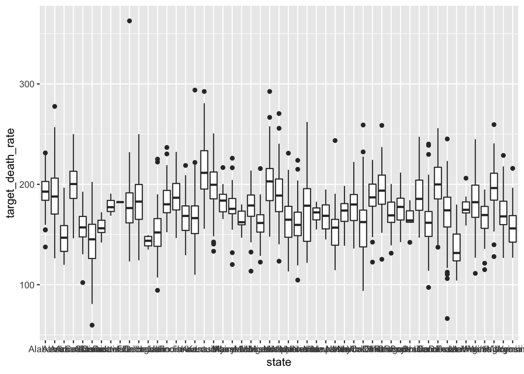

```r
cancer_raw %>%
  group_by(state) %>%
  ggplot(aes(x = state, y = target_death_rate)) +
  geom_boxplot()
```

**Literature search**

- Reference:
- Income: https://www.nejm.org/doi/pdf/10.1056/NEJMp1615069
- Race: https://www.ncbi.nlm.nih.gov/pubmed/28718431 https://www.ncbi.nlm.nih.gov/pubmed/28663175 https://www.ncbi.nlm.nih.gov/pubmed/25825511
- Education: https://www.ncbi.nlm.nih.gov/pubmed/28177482 https://www.ncbi.nlm.nih.gov/pubmed/28051039 https://www.ncbi.nlm.nih.gov/pubmed/27070947
- Statistics: https://www.ncbi.nlm.nih.gov/pubmed/28055103
- Gender: https://www.ncbi.nlm.nih.gov/pubmed/26346676
- Socioeconomic status: https://www.ncbi.nlm.nih.gov/pubmed/25288143

## Variable selection

**Check income distribution**

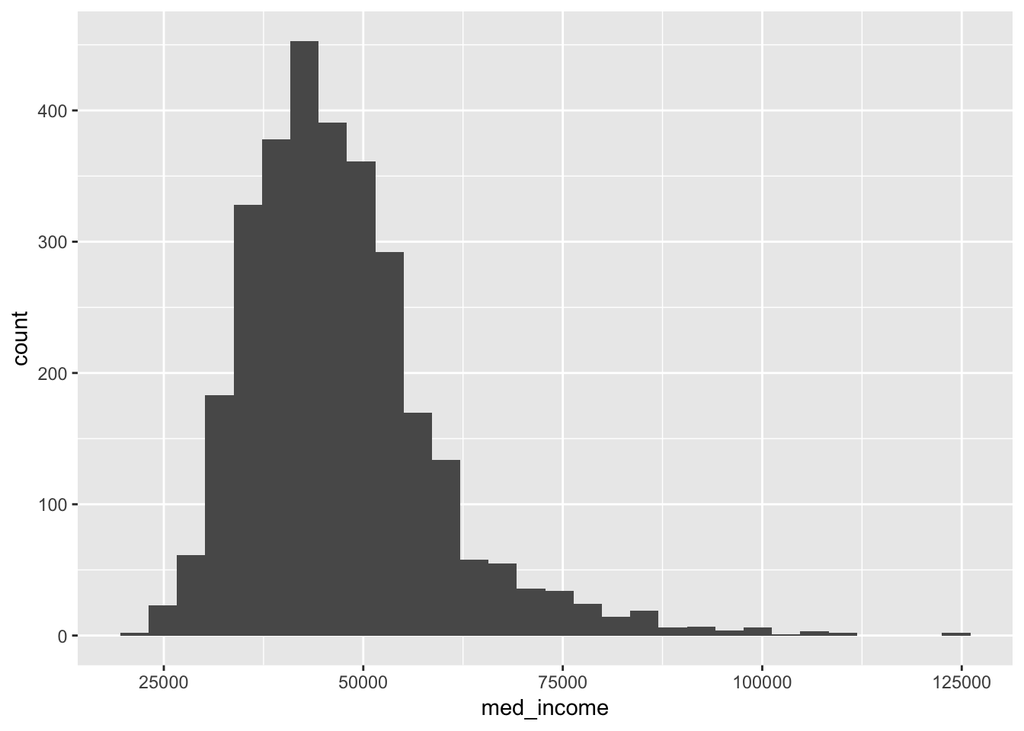

```r
cancer_raw %>%
  ggplot(aes(x = med_income)) +
  geom_histogram()
```

- Income classfication by https://finance.zacks.com/lower-middle-upper-class-income-levels-9877.html
1. Impoverished: $12,140 per person
2. Middle class: $39,560 per person
3. Upper-class: $72,126 per person
- Income classfication by https://www.ncbi.nlm.nih.gov/pubmed/26930647 Low income was defined as the lowest quartile of incomes (<$35,000)

**By county**

```r
cancer_county =
  cancer_raw %>%
  select(target_death_rate, incidence_rate, med_income, poverty_percent, median_age:median_age_female, avg_household_size:pct_married_households) %>%
  select(-pct_hs25_over, -pct_bach_deg25_over, -pct_employed16_over, -percent_married) %>%
  mutate(pct_upto_hs18_24 = pct_no_hs18_24 + pct_hs18_24,
         pct_above_hs18_24 = 100 - pct_upto_hs18_24,
         pct_with_coverage = pct_private_coverage + pct_public_coverage_alone,
         income_cat = ifelse(med_income < 35000, 0, 1)) %>%
  select(-(pct_no_hs18_24:pct_bach_deg18_24), -pct_above_hs18_24, -(pct_private_coverage:pct_public_coverage_alone), -med_income) %>%
  na.omit
```

**By state**

```r
cancer_state =
  cancer_raw %>%
  select(target_death_rate, state, incidence_rate, med_income, poverty_percent, median_age:median_age_female, avg_household_size:pct_married_households) %>%
  select(-pct_hs25_over, -pct_bach_deg25_over, -pct_employed16_over, -percent_married) %>%
  mutate(pct_upto_hs18_24 = pct_no_hs18_24 + pct_hs18_24,
         pct_above_hs18_24 = 100 - pct_upto_hs18_24,
         pct_with_coverage = pct_private_coverage + pct_public_coverage_alone,
         income_cat = ifelse(med_income < 35000, 0, 1)) %>%
  select(-(pct_no_hs18_24:pct_bach_deg18_24), -pct_above_hs18_24, -(pct_private_coverage:pct_public_coverage_alone)) %>%
  na.omit() %>%
  group_by(state) %>%
  summarize_all(median) %>%
  select(-state)
```

## Model Building

### Automatic Procedures

- Use alpha = 0.15 (exploratory analysis: be less stringent)

#### Regression model with all the variables

```r
fit_all = lm(target_death_rate ~ ., data = cancer_county)

summary(fit_all)
```

```
##
## Call:
## lm(formula = target_death_rate ~ ., data = cancer_county)
##
## Residuals:
##      Min       1Q   Median       3Q      Max
## -129.883  -11.469    0.163   12.142  126.523
##
## Coefficients:
##                         Estimate Std. Error t value Pr(>|t|)
## (Intercept)            72.058821  12.583888   5.726 1.13e-08 ***
## incidence_rate          0.219657   0.007547  29.104  < 2e-16 ***
## poverty_percent         1.036531   0.120008   8.637  < 2e-16 ***
## median_age             -0.004080   0.008394  -0.486 0.626969
## median_age_male        -0.241798   0.212259  -1.139 0.254726
## median_age_female       0.046110   0.209093   0.221 0.825476
## avg_household_size     -0.117704   1.007617  -0.117 0.907015
## pct_unemployed16_over   0.781391   0.153410   5.093 3.73e-07 ***
## pct_white               0.067342   0.058298   1.155 0.248127
## pct_black              -0.016016   0.057020  -0.281 0.778818
## pct_asian              -0.628303   0.178918  -3.512 0.000452 ***
## pct_other_race         -0.940645   0.124524  -7.554 5.56e-14 ***
## pct_married_households -0.220555   0.088361  -2.496 0.012611 *
## pct_upto_hs18_24        0.392918   0.038241  10.275  < 2e-16 ***
## pct_with_coverage      -0.194259   0.101672  -1.911 0.056145 .
## income_cat             -4.104213   1.507502  -2.723 0.006516 **
## ---
## Signif. codes:  0 '***' 0.001 '**' 0.01 '*' 0.05 '.' 0.1 ' ' 1
##
## Residual standard error: 20.77 on 3031 degrees of freedom
## Multiple R-squared:  0.4427, Adjusted R-squared:  0.4399
## F-statistic: 160.5 on 15 and 3031 DF,  p-value: < 2.2e-16
```

#### Stepwise

```r
step(fit_all, direction = 'backward') #select by AIC
```

```
## Start:  AIC=18501.85
## target_death_rate ~ incidence_rate + poverty_percent + median_age +
##     median_age_male + median_age_female + avg_household_size +
##     pct_unemployed16_over + pct_white + pct_black + pct_asian +
##     pct_other_race + pct_married_households + pct_upto_hs18_24 +
##     pct_with_coverage + income_cat
##
##                          Df Sum of Sq     RSS   AIC
## - avg_household_size      1         6 1307424 18500
## - median_age_female       1        21 1307440 18500
## - pct_black               1        34 1307453 18500
## - median_age              1       102 1307521 18500
## - median_age_male         1       560 1307978 18501
## - pct_white               1       576 1307994 18501
## <none>                                1307419 18502
## - pct_with_coverage       1      1575 1308993 18504
## - pct_married_households  1      2687 1310106 18506
## - income_cat              1      3197 1310616 18507
## - pct_asian               1      5319 1312738 18512
## - pct_unemployed16_over   1     11191 1318609 18526
## - pct_other_race          1     24614 1332032 18557
## - poverty_percent         1     32179 1339598 18574
## - pct_upto_hs18_24        1     45538 1352956 18604
## - incidence_rate          1    365362 1672781 19251
##
## Step:  AIC=18499.87
## target_death_rate ~ incidence_rate + poverty_percent + median_age +
##     median_age_male + median_age_female + pct_unemployed16_over +
##     pct_white + pct_black + pct_asian + pct_other_race + pct_married_households +
##     pct_upto_hs18_24 + pct_with_coverage + income_cat
##
##                          Df Sum of Sq     RSS   AIC
## - median_age_female       1        24 1307448 18498
## - pct_black               1        32 1307456 18498
## - median_age              1       102 1307527 18498
## - median_age_male         1       557 1307982 18499
## - pct_white               1       597 1308022 18499
## <none>                                1307424 18500
## - pct_with_coverage       1      1569 1308993 18502
## - pct_married_households  1      2873 1310297 18505
```

[output cut: 55 more lines]

```
##     income_cat
##
##                          Df Sum of Sq     RSS   AIC
## <none>                                1307574 18494
## - pct_with_coverage       1      1650 1309224 18496
## - pct_white               1      2296 1309870 18498
## - median_age_male         1      2355 1309928 18498
## - pct_married_households  1      2887 1310461 18499
## - income_cat              1      3171 1310744 18500
## - pct_asian               1      5778 1313352 18506
## - pct_unemployed16_over   1     11182 1318756 18518
## - pct_other_race          1     26394 1333968 18553
## - poverty_percent         1     32742 1340316 18568
## - pct_upto_hs18_24        1     47033 1354607 18600
## - incidence_rate          1    367928 1675502 19248
```

```
##
## Call:
## lm(formula = target_death_rate ~ incidence_rate + poverty_percent +
##     median_age_male + pct_unemployed16_over + pct_white + pct_asian +
##     pct_other_race + pct_married_households + pct_upto_hs18_24 +
##     pct_with_coverage + income_cat, data = cancer_county)
##
## Coefficients:
##            (Intercept)          incidence_rate         poverty_percent
##               70.81211                 0.21943                 1.03861
##        median_age_male   pct_unemployed16_over               pct_white
##               -0.20231                 0.77478                 0.08044
##              pct_asian          pct_other_race  pct_married_households
##               -0.61338                -0.93330                -0.22273
##       pct_upto_hs18_24       pct_with_coverage              income_cat
##                0.39445                -0.19434                -4.06923
```

```r
back_model = lm(target_death_rate ~ incidence_rate + poverty_percent +
    median_age_male + pct_unemployed16_over + pct_white + pct_asian +
    pct_other_race + pct_married_households + pct_upto_hs18_24 +
    pct_with_coverage + income_cat, data = cancer_county)

summary(back_model)
```

```
##
## Call:
## lm(formula = target_death_rate ~ incidence_rate + poverty_percent +
##     median_age_male + pct_unemployed16_over + pct_white + pct_asian +
##     pct_other_race + pct_married_households + pct_upto_hs18_24 +
##     pct_with_coverage + income_cat, data = cancer_county)
##
## Residuals:
##      Min       1Q   Median       3Q      Max
## -129.978  -11.453    0.127   12.095  126.386
##
## Coefficients:
##                         Estimate Std. Error t value Pr(>|t|)
## (Intercept)            70.812109  11.698781   6.053 1.60e-09 ***
## incidence_rate          0.219430   0.007509  29.223  < 2e-16 ***
## poverty_percent         1.038613   0.119140   8.718  < 2e-16 ***
## median_age_male        -0.202308   0.086539  -2.338 0.019465 *
## pct_unemployed16_over   0.774783   0.152081   5.095 3.71e-07 ***
## pct_white               0.080440   0.034847   2.308 0.021043 *
## pct_asian              -0.613378   0.167491  -3.662 0.000254 ***
## pct_other_race         -0.933301   0.119239  -7.827 6.84e-15 ***
## pct_married_households -0.222728   0.086039  -2.589 0.009680 **
## pct_upto_hs18_24        0.394452   0.037753  10.448  < 2e-16 ***
## pct_with_coverage      -0.194337   0.099299  -1.957 0.050430 .
## income_cat             -4.069227   1.500008  -2.713 0.006709 **
## ---
## Signif. codes:  0 '***' 0.001 '**' 0.01 '*' 0.05 '.' 0.1 ' ' 1
##
## Residual standard error: 20.76 on 3035 degrees of freedom
## Multiple R-squared:  0.4426, Adjusted R-squared:  0.4406
## F-statistic: 219.1 on 11 and 3035 DF,  p-value: < 2.2e-16
```

## Model Diagonsis

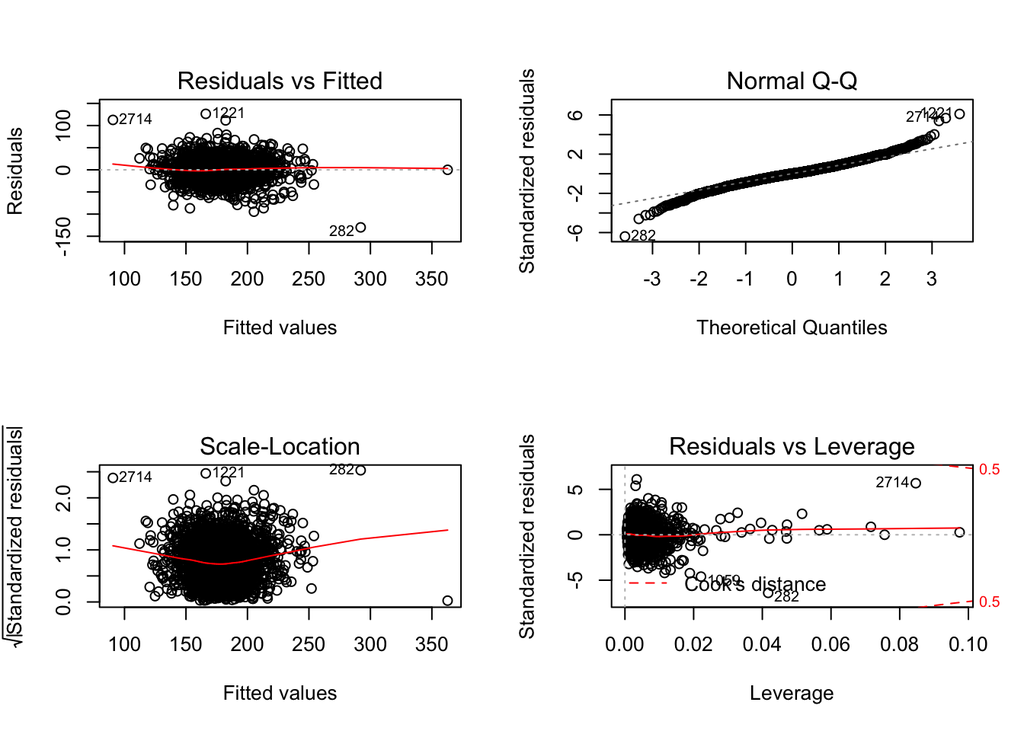

```r
par(mfrow = c(2,2))
plot(back_model)
```

## Model Validation

```r
cancer_county %>%
  modelr::bootstrap(n = 1000) %>%
  mutate(models = map(strap, ~lm(target_death_rate ~ incidence_rate + poverty_percent +
    median_age_male + pct_unemployed16_over + pct_white + pct_asian +
    pct_other_race + pct_married_households + pct_upto_hs18_24 +
    pct_with_coverage + income_cat, data = .x)),
         results = map(models, broom::tidy)) %>%
  select(-strap, -models) %>%
  unnest() %>%
  group_by(term) %>%
  summarize(boot_se = sd(estimate))
```

```
## # A tibble: 12 x 2
##    term                   boot_se
##    <chr>                    <dbl>
##  1 (Intercept)            15.2
##  2 incidence_rate          0.0130
##  3 income_cat              1.71
##  4 median_age_male         0.102
##  5 pct_asian               0.273
##  6 pct_married_households  0.101
##  7 pct_other_race          0.157
##  8 pct_unemployed16_over   0.193
##  9 pct_upto_hs18_24        0.0430
## 10 pct_white               0.0440
## 11 pct_with_coverage       0.128
## 12 poverty_percent         0.146
```

Check if income_cat is confounder or not?

```r
back_model = lm(target_death_rate ~ incidence_rate + poverty_percent +
    median_age_male + pct_unemployed16_over + pct_white + pct_asian +
    pct_other_race + pct_married_households + pct_upto_hs18_24 +
    pct_with_coverage + income_cat, data = cancer_county)

alt_model = lm(target_death_rate ~ incidence_rate + poverty_percent +
    median_age_male + pct_unemployed16_over + pct_white + pct_asian +
    pct_other_race + pct_married_households + pct_upto_hs18_24 +
    pct_with_coverage, data = cancer_county)

anova(alt_model, back_model)
```

```
## Analysis of Variance Table
##
## Model 1: target_death_rate ~ incidence_rate + poverty_percent + median_age_male +
##     pct_unemployed16_over + pct_white + pct_asian + pct_other_race +
##     pct_married_households + pct_upto_hs18_24 + pct_with_coverage
## Model 2: target_death_rate ~ incidence_rate + poverty_percent + median_age_male +
##     pct_unemployed16_over + pct_white + pct_asian + pct_other_race +
##     pct_married_households + pct_upto_hs18_24 + pct_with_coverage +
##     income_cat
##   Res.Df     RSS Df Sum of Sq      F   Pr(>F)
## 1   3036 1310744
## 2   3035 1307574  1    3170.6 7.3593 0.006709 **
## ---
## Signif. codes:  0 '***' 0.001 '**' 0.01 '*' 0.05 '.' 0.1 ' ' 1
```